# 仮説4

Published

2026-11-13

本報告書はスライドが報告している分析に沿って、より詳細に分析を報告する。

**文化的妥当性の解釈を訂正**

文化的妥当性の保存値は既に逆転済みであり、**高得点ほど文化的に妥当**である。H4では追加逆転を行わない。再推定した人手版−LLM版の類似度傾き差は **+0.739 [0.032, 1.445]** であり、類似度と文化的妥当性の関係が人手版で相対的により正方向である。ただし、各版単独の傾きの区間は0を含み、人手版の文化的妥当性が全般に高いとは結論できない。項目別の文化的不適切さチェックは別の0/1アウトカムであり、逆転しない。

OCQだけに適用する除外を維持し、対象者は **363人 → 330人**。同じ回答者の他尺度は残すため、市民全体の1,859人は変わらない。

## 1 目的

仮説4は、心理尺度の項目について、人手版翻訳の逆翻訳が、LLM版翻訳の逆翻訳よりも、英語原文と類似しているかを検証する。「類似している」とは、MPNetなどのembeddingモデルにて計算したコサイン類似度が大きいことである。プレレジの予測はポジティブであり、下記の不等式で表される。

$$\mathrm{Similarity}(\mathrm{Origin},\mathrm{Back\text{-}translation}_H) > \mathrm{Similarity}(\mathrm{Origin},\mathrm{Back\text{-}translation}_L)$$

### 1.1 探索的分析

探索的分析は別で、仮説４の検定とは独立しており、予測を検証することではなく、embedding上の文間類似度が人の主観的評価とどのように関連することを探る。

1. 原文に近い翻訳ほど、自然さ・意味的忠実性・文化的妥当性・選択肢適合の評定が高いか。
2. １での類似度と評定の関係は、人手版とLLM版で異なるか（交互作用を検討）。
3. 原文に近い翻訳ほど、選好やLLM版の指摘(guessing which is LLM translation)を予測するか。
4. 原文に近い翻訳ほど、専門家が各項目の問題点(意味の不一致・理解しにくい・文化の不適切さ)をあげる確率(flagging problem)を予測するか。

## 2 データの読み込み

データと研究資料の公開先は [OSFプロジェクト](https://osf.io/hn4fr/) であり、解析データのアップロードは準備中である。GitHubにはデータを収録せず、集計表と埋め込みデータをローカルの `analysis/h4/data/published/` に配置して実行する。埋め込みモデルの再取得には `scripts/download_models.sh` を用いる。

```r
library(readr)
gaps <- read_csv(published("mpnet_item_delta.csv"), show_col_types = FALSE)
boot <- read_csv(published("bootstrap_primary.csv"), show_col_types = FALSE)
spec <- read_csv(published("specification_curve_primary.csv"), show_col_types = FALSE)
beta <- read_csv(published("beta_density_primary.csv"), show_col_types = FALSE)
slopes <- read_csv(published("judgment_slopes.csv"), show_col_types = FALSE)
gap_analysis <- read_csv(published("gap_models_n1859.csv"), show_col_types = FALSE)
screen <- read_csv(published("survey_screen_n1859.csv"), show_col_types = FALSE)
interactions_analysis <- read_csv(published("similarity_interactions_n1859.csv"), show_col_types = FALSE)
raw_ratings <- read_csv(published("raw_rating_ordinal_n1859.csv"), show_col_types = FALSE)
raw_choices <- read_csv(published("raw_choice_logit_n1859.csv"), show_col_types = FALSE)
raw_flags <- read_csv(published("raw_flag_logit_n1859.csv"), show_col_types = FALSE)
wass <- read_csv(published("wasserstein_comparison.csv"), show_col_types = FALSE)
gaps$scale_id <- sprintf("%02d", as.integer(gaps$scale_id))
c(
  item_rows = nrow(gaps),
  specifications = nrow(spec),
  analysis_citizens = screen$n_respondents[screen$cut == "citizen_two_rule"],
  sensitivity_citizens = screen$n_respondents[screen$cut == "citizen_three_rule"]
)
```

```
           item_rows       specifications    analysis_citizens
                1016                   24                 1859
sensitivity_citizens
                1211
```

## 3 パイプライン

$$\cos(\mathbf{a},\mathbf{b})=\frac{\mathbf{a}\cdot\mathbf{b}}{\lVert\mathbf{a}\rVert\,\lVert\mathbf{b}\rVert}$$

5. 項目差は、人手の逆翻訳コサインからLLMの逆翻訳コサインを引いたものである。正(>0)なら、人手の逆翻訳の方が原文に近い。
6. 報告する指標は、その差のREML切片である。尺度をランダム切片にする。
7. 符号の確認は、尺度ブートストラップ、ベータ回帰、また、他の埋め込みモデルMiniLM、LaBSE、E5を用いることである。
8. 探索的分析で用いる市民データは1,859人である。割り当て項目の完答に加え、注意確認と回答時間の2基準を使う。提示順が保存されていないため、連続同一回答の基準は使わない。3基準を使った1,211人は感度分析である。セットCのチョコレート摂取頻度で6を選んだ回答者は、OCQに限って除外する。OCQの対象者は主分析で363人から330人、感度分析で198人から192人となり、同じ回答者の他尺度は残す。専門家は106人で変わらない。
9. 探索的分析で使用したモデルは、観測された結果をそのまま使う。1〜5評定は順序アウトカム、問題チェック・選好・LLMであるかどうか(guessing LLM)は二値アウトカムである。各翻訳には、その翻訳自身の原文との類似度を対応させる。

## 4 結果の要約

### 4.1 判定表

下記の表は仮説4の確認的検定の結果である。

| 確認 | 人手 − LLM | 95%区間 | 役割 |
| --- | --- | --- | --- |
| REML、TIVSを除く | −0.041 | [−0.060, −0.022] | 確認的。区間は0を含まない |
| 尺度ブートストラップ、10,000回 | −0.038 | [−0.059, −0.025] | 同じ比較 |
| ベータ回帰 | −0.042 | [−0.061, −0.021] | 同じ比較 |
| MiniLM | −0.055 | [−0.077, −0.033] | 他モデル確認 |
| LaBSE | −0.071 | [−0.106, −0.036] | 他モデル確認 |
| E5 | −0.006 | [−0.009, −0.004] | 他モデル確認 |
| 22尺度、TIVSを戻す | −0.040 | [−0.058, −0.022] | 頑健性確認 |

486項目の標本平均コサインは、人手 0.896、LLM 0.934 である。

探索的分析で用いたモデルは、国里先生の仮説1・3と同じモデルの組み方を使う。各版の観測評定を1行にし、人手版を $x=+0.5$、LLM版を $x=-0.5$ とする。回答者と尺度ごとに版効果(llm vs. human)を変化させ、回答者×尺度のペア切片を置く。1〜5評定には累積ロジット混合モデルを使う。選好、LLM翻訳であるかどうか、専門家チェックの0/1アウトカムには二項ロジット混合モデルを使い、データ構造に対応する回答者・尺度・項目・ペアのランダム効果を置く。類似度は、その版自身の尺度平均逆翻訳コサインを両版で標準化した値である。

| 評定項目 | 人手版の傾き | LLM版の傾き | 人手 − LLMの傾き |
| --- | --- | --- | --- |
| 市民の自然さ | −0.137 [−0.361, 0.087] | −0.034 [−0.537, 0.469] | −0.103 [−0.575, 0.369] |
| 専門家の自然さ | +0.293 [−0.015, 0.600] | −0.382 [−1.099, 0.336] | +0.674 [−0.059, 1.408] |
| 専門家の意味的忠実性 | +0.057 [−0.234, 0.348] | −0.216 [−0.944, 0.513] | +0.273 [−0.497, 1.043] |
| 専門家の文化的妥当性 | +0.194 [−0.097, 0.486] | −0.544 [−1.198, 0.110] | **+0.739 [0.032, 1.445]** |
| 専門家の選択肢適合 | **+0.348 [0.115, 0.580]** | +0.013 [−0.539, 0.566] | +0.334 [−0.255, 0.924] |

主観的評定の探索的分析では、次の2点を区別して報告する。

- **専門家の選択肢適合は、人手版の類似度と正に関連する：+0.348 [0.115, 0.580]。** 人手版内の単純傾きの区間は0を含まない。一方、人手版−LLM版の傾き差 +0.334 [−0.255, 0.924] は0を含むため、この関連が人手版でLLM版より強いとは結論できない。
- **専門家の文化的妥当性では、人手版−LLM版の類似度傾き差が正である：+0.739 [0.032, 1.445]。** 保存値は高いほど好評価であり、類似度と文化的妥当性の関係が人手版で相対的により正方向である。ただし、各版単独の傾きの区間は0を含む。

市民の自然さには、0から分かれた類似度傾きはない。選好とLLM版の指摘も観測された二値アウトカムを使い、人手版とLLM版の類似度を別々に入れる。市民では、いずれの類似度区間も0を含む。

### 4.2 結論の図

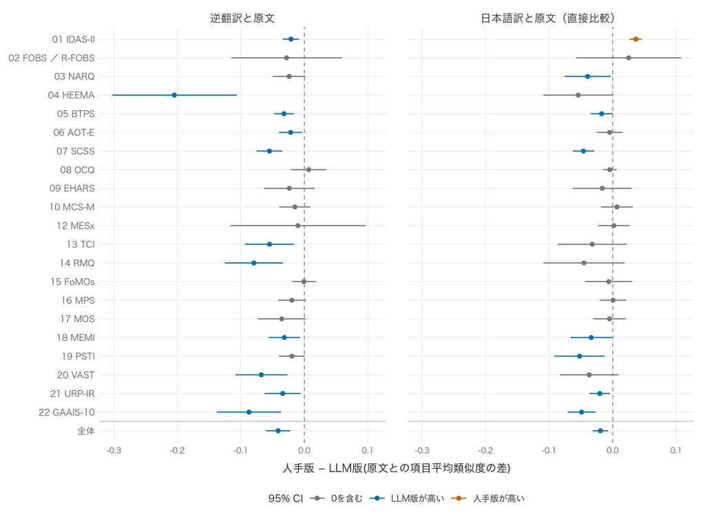

TIVSを除いた21尺度の類似度差と95%信頼区間。左：逆翻訳、右：日本語訳の直接比較。最下段：全体。

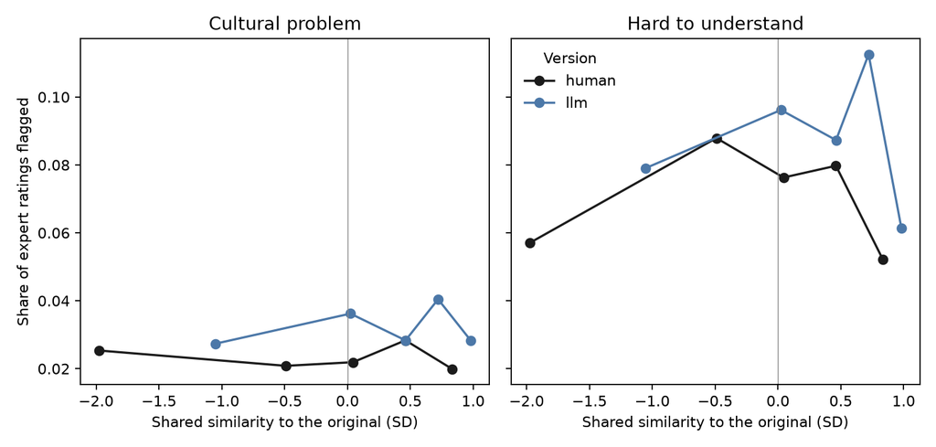

共有の類似度の上のチェック割合

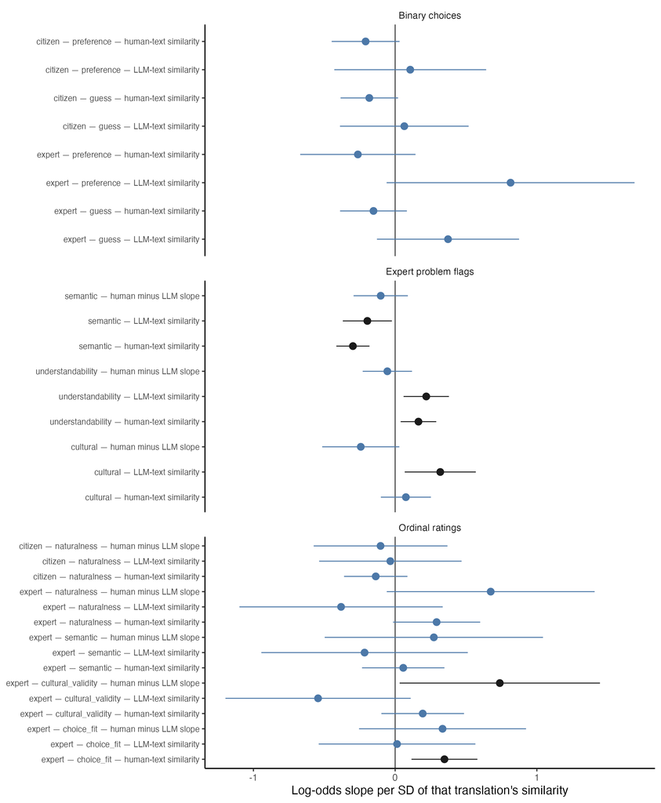

生の順序評定と二値アウトカムを、各翻訳自身の類似度で予測した傾き。黒は0を含まない

### 4.3 結論

**LLMの英語逆翻訳の方が英語原文に近い。**差は約0.04である。仮説4の予測とは逆であった。ブートストラップ、ベータ回帰、他の3つの埋め込み、TIVSを戻した22尺度も、同じ符号である。**仮説4の確認的検定は支持されなかった。**

**専門家の選択肢適合では、人手版の逆翻訳が原文に近い尺度ほど、選択肢適合の評定が高い（傾き +0.348 [0.115, 0.580]）。** これは人手版内の正の関連を示す探索的所見である。ただし、LLM版との傾き差は0を含むため、人手版の関連の方が強いとは結論できない。

探索分析では、参加者の主観的評定につきまして、類似度傾きの版間差が0を含まないのは専門家の文化的妥当性だけである。**文化的妥当性の保存値は既に逆転済みであり、高いほど好評価である。正の交互作用は、類似度と文化的妥当性の関係が人手版で相対的により正方向であることを示す。** ただし、文化的妥当性の両版の単純傾きの区間は0を含むため、類似度が高いほど各版の文化的妥当性が高くなるとまでは言えない。それに対して、市民の自然さ、選好、LLM版の指摘の類似度区間は0を含み、これらと原文との類似度の間に明確な関連を示す証拠は得られていない。

また、専門家の問題チェックでは、各版自身の類似度が高いほど、意味不一致チェックは両版で少なく、理解しにくさチェックは両版で多い。文化チェックはLLM版の類似度とともに増えるが、人手版の傾きと版間の傾き差は0を含む。

## 5 判定の規則

| 95%区間 | 確認的な判定 |
| --- | --- |
| 下限 > 0 | 予測を支持する。人手の逆翻訳の方が近い |
| 上限 < 0 | 予測と逆。LLMの逆翻訳の方が近い |
| 0を含む | 予測は支持されない |

この報告書では、REMLのWald区間を使用している。ブートストラップは同じ差の、尺度のあと項目の平均である。

## 6 解析方法

項目 $i$、尺度 $s$ について

$$\Delta_{is}=\cos(E_i,H^{\mathrm{back}}_i)-\cos(E_i,L^{\mathrm{back}}_i)$$

$$\Delta_{is}=\mu+u_s+\varepsilon_{is}$$

ここで、$i$ は項目、$s$ は尺度、$E_i$ は英語原文、$H_i^{\mathrm{back}}$ と $L_i^{\mathrm{back}}$ はそれぞれ人手日本語版とLLM日本語版の英語逆翻訳、$\cos(\cdot,\cdot)$ はコサイン類似度である。$\Delta_{is}$ は人手−LLMの項目差、$\mu$ は21尺度の母平均差、$u_s$ は平均0・分散 $\sigma_u^2$ の尺度ランダム切片、$\varepsilon_{is}$ は平均0・分散 $\sigma_\varepsilon^2$ の項目残差である。報告する確認的推定値は $\mu$ であり、REMLで当てはめる。

探索の評定データは、回答者×尺度×版につき1行である。人手版を $x=+0.5$、LLM版を $x=-0.5$ とし、$z_{sv}$ はその版自身の尺度平均類似度を両版で標準化した値とする。累積ロジット混合モデルは

$$\operatorname{logit}\Pr(Y_{psv}\leq k)=\theta_k-\left[\beta_xx_v+\beta_zz_{sv}+\beta_{xz}x_vz_{sv}+\beta_oo_p+b_p+b_{px}x_v+b_s+b_{sx}x_v+b_{ps}\right]$$

記号は次の意味である。

| 記号 | 定義 |
| --- | --- |
| $p,s,v$ | 回答者、尺度、翻訳版。$v$ は人手版またはLLM版 |
| $Y_{psv}$ | 回答者 $p$ が尺度 $s$ の版 $v$ に付けた観測評定。値は1〜5 |
| $k$ | 累積確率を区切る境界。5件法なので $k=1,2,3,4$ |
| $\Pr(Y_{psv}\leq k)$ | 評定がカテゴリー $k$ 以下になる確率 |
| $\operatorname{logit}(q)$ | $\log\{q/(1-q)\}$ |
| $\theta_k$ | 第 $k$ 閾値。$\theta_1<\theta_2<\theta_3<\theta_4$ |
| $x_v$ | 版の効果符号。人手版 $+0.5$、LLM版 $-0.5$ |
| $z_{sv}$ | 版 $v$ の尺度 $s$ における平均逆翻訳コサインを、21尺度×2版の42値で標準化した値 |
| $o_p$ | LLM版を先に回答した場合1、人手版を先に回答した場合0 |
| $\beta_x$ | 平均的な人手版−LLM版効果。類似度が平均値のときの対数オッズ差 |
| $\beta_z$ | 両版を平均した類似度傾き |
| $\beta_{xz}$ | 人手版の類似度傾き−LLM版の類似度傾き |
| $\beta_o$ | LLM-firstとhuman-firstの固定差 |
| $b_p,b_s$ | 回答者と尺度のランダム切片 |
| $b_{px},b_{sx}$ | 回答者別・尺度別の版効果のずれ |
| $b_{ps}$ | 回答者 $p$ ×尺度 $s$ のペア切片。両版に共通する評定傾向 |

各ランダム効果は平均0の正規分布に従うとし、切片と版傾きは別々の項として推定して相関を置かない。人手版の類似度傾きは $\beta_z+0.5\beta_{xz}$、LLM版は $\beta_z-0.5\beta_{xz}$ である。仮説1・3と同じペア構造を踏襲するが、ここではベイズ推定ではなく、Laplace近似による累積混合モデルを用いる。

選好とLLM翻訳であるかどうかは、回答者×尺度につき1つの二値判断なので、二項ロジット混合モデルを用いて

$$\operatorname{logit}\Pr(C_{ps}=1)=\alpha_0+\alpha_Hz_{sH}+\alpha_Lz_{sL}+\alpha_oo_p+a_p+a_s$$

とする。$C_{ps}=1$ は、選好モデルでは人手版を選んだこと、指摘モデルではLLM版を正しく指摘したことを表す。$\alpha_0$ は基準対数オッズ、$z_{sH}$ と $z_{sL}$ は人手版・LLM版それぞれの尺度類似度、$\alpha_H$ と $\alpha_L$ はその傾き、$\alpha_o$ は提示順効果、$a_p$ と $a_s$ は平均0の回答者・尺度ランダム切片である。

専門家チェックは項目ごとの0/1観測を残し、二項ロジット混合モデルを用いて

$$\operatorname{logit}\Pr(F_{psiv}=1)=\gamma_0+\gamma_xx_v+\gamma_zz_{isv}+\gamma_{xz}x_vz_{isv}+\gamma_oo_p+c_p+c_{px}x_v+c_s+c_{sx}x_v+c_i+c_{pi}$$

とする。$F_{psiv}=1$ は回答者 $p$ が尺度 $s$ の項目 $i$・版 $v$ に問題をチェックしたこと、$z_{isv}$ はその翻訳自身の項目コサインを486項目×2版の972値で標準化した値である。$\gamma_0$ は基準対数オッズ、$\gamma_x$ は平均的な版効果、$\gamma_z$ は両版平均の類似度傾き、$\gamma_{xz}$ は人手版−LLM版の類似度傾き差、$\gamma_o$ は提示順効果である。$c_p,c_s,c_i$ は平均0の回答者・尺度・項目ランダム切片、$c_{px},c_{sx}$ は回答者別・尺度別の版効果、$c_{pi}$ は回答者×項目のペア切片である。意味不一致、理解しにくさ、文化の不適切さの3チェックは別々に当てはめる。

**文化的妥当性の符号付けに関する訂正（2026-10-31）：** 質問文は「馴染みのない慣用句・比喩・例示が使われている」という負項目だが、Qualtricsの保存値は既に「まったくそう思わない＝5、とてもそう思う＝1」と逆転済みである。したがって、保存値は高いほど文化的に妥当な向きである。H4では追加の逆転を行わない。項目別の文化的不適切さチェック（0/1）は別のアウトカムであり、逆転しない。

```r
back <- gaps[gaps$comparison == "back_translation", ]
primary <- back[back$in_primary, ]
stopifnot(nrow(back) == 508L)
stopifnot(nrow(primary) == 486L)
stopifnot(length(unique(primary$scale_id)) == 21L)
stopifnot(!any(primary$scale_id == "11"))
c(
  items_before = nrow(back),
  items_after = nrow(primary),
  removed = nrow(back) - nrow(primary),
  scales = length(unique(primary$scale_id)),
  human = mean(primary$human),
  llm = mean(primary$llm),
  item_mean = mean(primary$delta)
)
```

```
items_before  items_after      removed       scales        human          llm
508.00000000 486.00000000  22.00000000  21.00000000   0.89573845   0.93357444
   item_mean
 -0.03783599
```

TIVSを除いた486項目では、人手の逆翻訳コサインの平均は約0.896、LLMは約0.934である。正の項目差は、人手の逆翻訳の方が近い。

### 6.1 確認的推定

```r
library(lme4)
fit <- lmer(delta ~ 1 + (1 | scale_id), data = primary, REML = TRUE)
est <- fixef(fit)[[1]]
se <- sqrt(vcov(fit)[1, 1])
ci <- est + c(-1.96, 1.96) * se
stopifnot(abs(est - (-0.041283224127389495)) < 1e-4)
c(estimate = est, se = se, low = ci[1], high = ci[2])
```

```
    estimate           se          low         high
-0.041283252  0.009728224 -0.060350571 -0.022215933
```

引用する結果は −0.041（SE 0.010）、区間 [−0.060, −0.022] である。上限は0より小さい。

TIVSを戻した508項目は付録の当てはめである。

```r
fit_22 <- lmer(delta ~ 1 + (1 | scale_id), data = back, REML = TRUE)
est_22 <- fixef(fit_22)[[1]]
se_22 <- sqrt(vcov(fit_22)[1, 1])
ci_22 <- est_22 + c(-1.96, 1.96) * se_22
stopifnot(abs(est_22 - (-0.04004756)) < 1e-3)
c(estimate = est_22, se = se_22, low = ci_22[1], high = ci_22[2])
```

```
    estimate           se          low         high
-0.040047561  0.009332341 -0.058338950 -0.021756173
```

符号は同じである。

### 6.2 尺度別の図

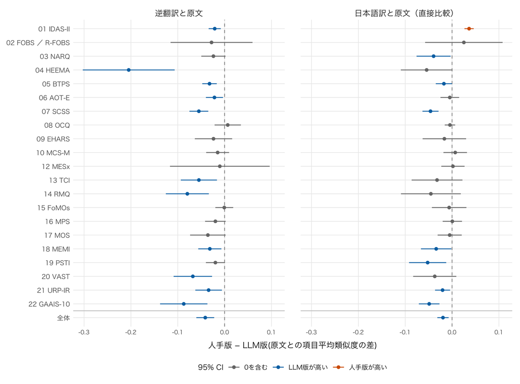

```r
source(file.path(getwd(), "..", "scripts", "plot_mean_item_gap_ja.R"))
mean_gap_ja <- build_mean_item_gap_ja(file.path(getwd(), ".."), save = FALSE)
mean_gap_ja$plot
```

尺度別の横線は対応する項目差の平均の95% t信頼区間、最下段「全体」は尺度のランダム切片を含む既存のREML推定値と95% Wald信頼区間である。青は区間全体が負（LLM版が高い）、橙は正（人手版が高い）、灰は0を含む。尺度別区間は探索的で、多重比較補正は行っていない。

左が逆翻訳と原文の比較である。21尺度のうち20の尺度平均は負である。右は日本訳そのものと原文の比較で、参考である。

### 6.3 同じ符号の確認

コサインは0.8から1.0に積もる。

```r
c(
  human_mean = mean(primary$human),
  human_median = median(primary$human),
  llm_mean = mean(primary$llm),
  llm_median = median(primary$llm)
)
```

```
  human_mean human_median     llm_mean   llm_median
   0.8957385    0.9174487    0.9335744    0.9519829
```

```r
beta[beta$comparison == "back_translation", c("mean_difference", "ci_low", "ci_high")]
```

```
# A tibble: 1 × 3
  mean_difference  ci_low ci_high
            <dbl>   <dbl>   <dbl>
1         -0.0418 -0.0605 -0.0213
```

```r
c(
  bootstrap = boot$observed_mean,
  low = boot$ci_low,
  high = boot$ci_high,
  positive_draws = boot$proportion_positive
)
```

```
     bootstrap            low           high positive_draws
   -0.03783599    -0.05869987    -0.02450336     0.00000000
```

```r
stopifnot(boot$proportion_positive == 0)
```

10,000回の抽出で、正の平均は一度も出ない。ベータ回帰の差も負である。

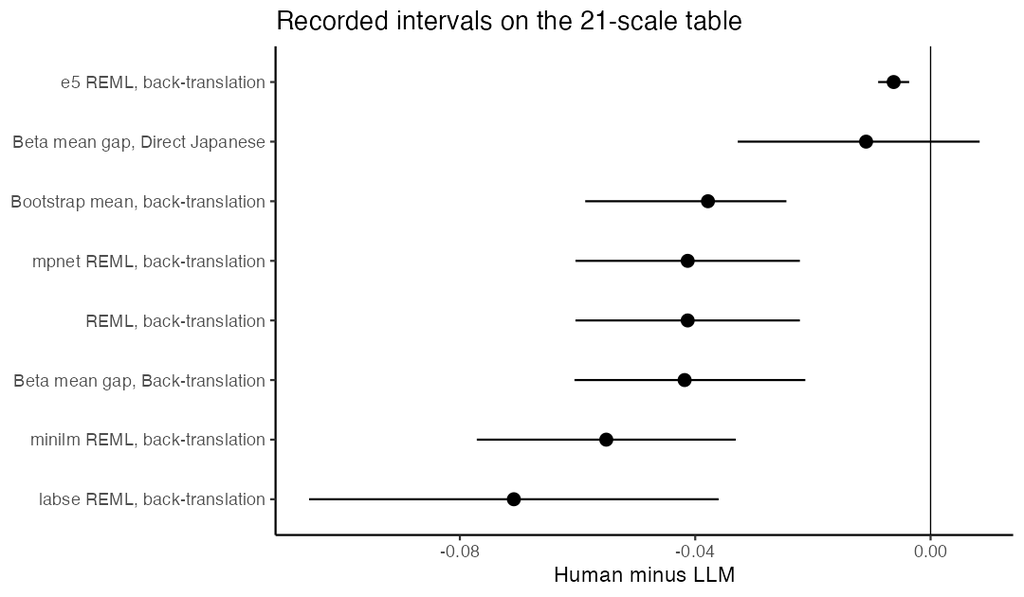

MPNetの確認と比較の森

### 6.4 他埋め込みモデルでも同様の結果が得られた

```r
cosine_back <- spec[
  spec$metric == "cosine" & spec$comparison == "back_translation",
  c("short_name", "estimate", "ci_low", "ci_high", "analysis_tier")
]
cosine_back <- cosine_back[order(match(cosine_back$short_name, c("mpnet", "minilm", "labse", "e5"))), ]
stopifnot(all(cosine_back$estimate < 0))
stopifnot(all(spec$sign == "negative"))
cosine_back
```

```
# A tibble: 4 × 5
  short_name estimate   ci_low  ci_high analysis_tier
  <chr>         <dbl>    <dbl>    <dbl> <chr>
1 mpnet      -0.0413  -0.0604  -0.0222  confirmatory
2 minilm     -0.0551  -0.0771  -0.0331  robustness
3 labse      -0.0708  -0.106   -0.0360  robustness
4 e5         -0.00628 -0.00892 -0.00364 robustness
```

4つのモデル、逆翻訳と直接の日英、コサインと角距離と正規化ユークリッドである。E5が0に最も近くであるが、負のままである。

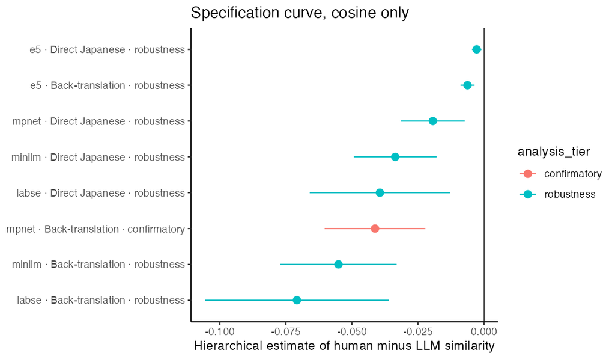

階層コサイン推定の仕様曲線

### 6.5 探索的分析1：類似度と主観的評定

分析データの市民は1,859人である。割り当て項目の完答に加え、注意確認と回答時間の2つの除外基準を使う。連続同一回答は使わない。項目の提示順はランダマイズされていたが記録がないため、原版の並びで走査したフラグは分析に入れない。専門家は元からそのフラグを使っておらず、106人である。3基準をすべて満たした市民1,211人は感度分析である。

```r
rating_focus <- raw_ratings[
  raw_ratings$term %in% c("sim_human", "sim_llm", "x:sim"),
  c("outcome", "audience", "term", "estimate", "ci_low", "ci_high", "n")
]
rating_focus
```

```
# A tibble: 15 × 7
   outcome           audience term      estimate  ci_low ci_high     n
   <chr>             <chr>    <chr>        <dbl>   <dbl>   <dbl> <dbl>
 1 naturalness       citizen  x:sim      -0.103  -0.575   0.369  13014
 2 naturalness       citizen  sim_llm    -0.0340 -0.537   0.469  13014
 3 naturalness       citizen  sim_human  -0.137  -0.361   0.0867 13014
 4 naturalness       expert   x:sim       0.674  -0.0593  1.41     740
 5 naturalness       expert   sim_llm    -0.382  -1.10    0.336    740
 6 naturalness       expert   sim_human   0.293  -0.0149  0.600    740
 7 semantic          expert   x:sim       0.273  -0.497   1.04     740
 8 semantic          expert   sim_llm    -0.216  -0.944   0.513    740
 9 semantic          expert   sim_human   0.0571 -0.234   0.348    740
10 cultural_validity expert   x:sim       0.739   0.0317  1.45     740
11 cultural_validity expert   sim_llm    -0.544  -1.20    0.110    740
12 cultural_validity expert   sim_human   0.194  -0.0971  0.486    740
13 choice_fit        expert   x:sim       0.334  -0.255   0.924    740
14 choice_fit        expert   sim_llm     0.0134 -0.539   0.566    740
15 choice_fit        expert   sim_human   0.348   0.115   0.580    740
```

表の係数は1標準偏差だけ類似度が高いときに、より高い評定カテゴリーへ移る累積対数オッズの変化である。`sim_human` は人手版の傾き、`sim_llm` はLLM版の傾き、`x:sim` は前者から後者を引いた傾き差である。

- **市民の自然さ（13,014評定、1,859人、21尺度）。** 人手版は −0.137 [−0.361, 0.087]、LLM版は −0.034 [−0.537, 0.469]、傾き差は −0.103 [−0.575, 0.369] である。3区間とも0を含む。したがって、逆翻訳が原文に近いほど市民の自然さ評定が一貫して上がる、または下がるとは言えず、その関係が人手版とLLM版で異なるとも言えない。
- **専門家の自然さ（740評定、106人、21尺度）。** 人手版は +0.293 [−0.015, 0.600]、LLM版は −0.382 [−1.099, 0.336]、傾き差は +0.674 [−0.059, 1.408] である。点推定の向きは版間で異なるが、すべて0を含むため、版ごとの関連も版間差も確定しない。
- **専門家の意味的忠実性。** 人手版は +0.057 [−0.234, 0.348]、LLM版は −0.216 [−0.944, 0.513]、傾き差は +0.273 [−0.497, 1.043] である。類似度と意味的忠実性の関連は、特定できない。
- **専門家の文化的妥当性項目。** 人手版は +0.194 [−0.097, 0.486]、LLM版は −0.544 [−1.198, 0.110] で、各版の区間は0を含む。一方、傾き差は +0.739 [0.032, 1.445] で0を含まない。**訂正後の解釈：保存値は高いほど文化的に妥当であるため、人手版ではLLM版よりも、類似度と文化的妥当性の関係がより正方向である。** ただし、各版単独の傾きは0と異なるとは言えず、人手版の文化的妥当性が全般に高いことを示す結果でもない。
- **専門家の選択肢適合。** 人手版は +0.348 [0.115, 0.580] で0を含まず、原文に近い人手逆翻訳ほど回答選択肢の適合評定が高い。LLM版は +0.013 [−0.539, 0.566] で0を含む。ただし傾き差は +0.334 [−0.255, 0.924] で0を含むため、人手版の関連がLLM版より強いとは結論できない。 人手版の尺度平均類似度が1標準偏差高い場合、より高い評定カテゴリーへのオッズ比は1.42 [1.12, 1.79] である。+0.348は類似度の傾きであり、切片や評定点の差ではない。「人手版内で正の関連がある」と「その関連がLLM版より強い」は別の検定である。

以上から、版間の類似度傾き差が0を含まないのは文化的妥当性項目だけである。選択肢適合では人手版単独の傾きが0を含まないが、版間差は0を含む。

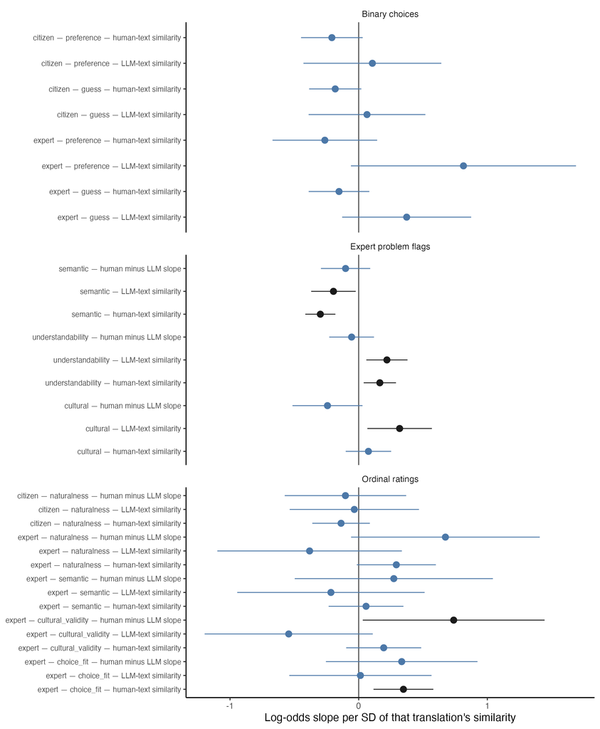

生のアウトカムの傾き

### 6.6 探索的分析2：Token間Wasserstein距離

Wasserstein距離が大きいほど、Tokenの点群は離れている。コサインとは向きが逆なので、予測子は距離を反転する。正は、人手の点群の方が近い。この表はTIVSと連続同一回答の除外を含む感度分析であり、21尺度・市民1,859人の分析データの傾きではない。Wasserstein-1とWasserstein-2を同時に入れたモデルは、コサインの代わりにはならない。

```r
token <- wass[
  wass$term %in% c("delta_z", "w1_z", "w2_z"),
  c("outcome", "predictor", "estimate", "ci_low", "ci_high", "includes_zero", "n")
]
token
```

```
# A tibble: 20 × 7
   outcome              predictor estimate   ci_low  ci_high includes_zero     n
   <chr>                <chr>        <dbl>    <dbl>    <dbl> <lgl>         <dbl>
 1 naturalness_gap      cosine_s…  -0.0563 -1.49e-1  0.0363  TRUE           4763
 2 naturalness_gap      w1_item_…  -0.132  -3.11e-1  0.0471  TRUE           4763
 3 naturalness_gap      w2_item_…  -0.137  -3.18e-1  0.0445  TRUE           4763
 4 naturalness_gap      w1_and_w2   1.09   -2.49e+0  4.66    TRUE           4763
 5 naturalness_gap      w1_and_w2  -1.24   -4.87e+0  2.39    TRUE           4763
 6 expert_choice_fit_g… cosine_s…   0.134   1.44e-2  0.253   FALSE           381
 7 expert_choice_fit_g… w1_item_…   0.237  -1.16e-3  0.475   TRUE            381
 8 expert_choice_fit_g… w2_item_…   0.245   3.44e-3  0.486   FALSE           381
 9 expert_choice_fit_g… w1_and_w2  -1.59   -6.58e+0  3.40    TRUE            381
10 expert_choice_fit_g… w1_and_w2   1.86   -3.21e+0  6.93    TRUE            381
11 preference           cosine_s…  -0.236  -4.93e-1  0.0205  TRUE           4764
12 preference           w1_item_…  -0.499  -9.95e-1 -0.00272 FALSE          4764
13 preference           w2_item_…  -0.499  -1.00e+0  0.00603 TRUE           4764
14 preference           w1_and_w2  -3.28   -1.11e+1  4.57    TRUE           4764
15 preference           w1_and_w2   2.83   -5.14e+0 10.8     TRUE           4764
16 guess                cosine_s…  -0.194  -4.02e-1  0.0141  TRUE           4764
17 guess                w1_item_…  -0.387  -7.93e-1  0.0187  TRUE           4764
18 guess                w2_item_…  -0.385  -7.99e-1  0.0277  TRUE           4764
19 guess                w1_and_w2  -3.19   -1.06e+1  4.27    TRUE           4764
20 guess                w1_and_w2   2.85   -4.72e+0 10.4     TRUE           4764
```

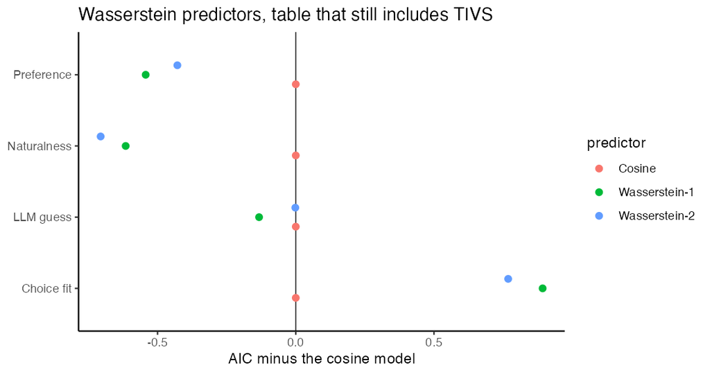

コサインとトークン距離

### 6.7 探索的分析3：共通類似度と専門家問題チェック

| チェック | 人手の五分位 | LLMの五分位 |
| --- | --- | --- |
| 理解しにくさ | 5.7%、8.8%、7.6%、8.0%、5.2% | 7.9%、9.6%、8.7%、11.3%、6.1% |
| 文化 | 2.5%、2.1%、2.2%、2.8%、2.0% | 2.7%、3.6%、2.8%、4.0%、2.8% |

LLMの線は右に寄る。理解しにくさはその線の中ほどで高く、最も近い五分位では両方が下がる。

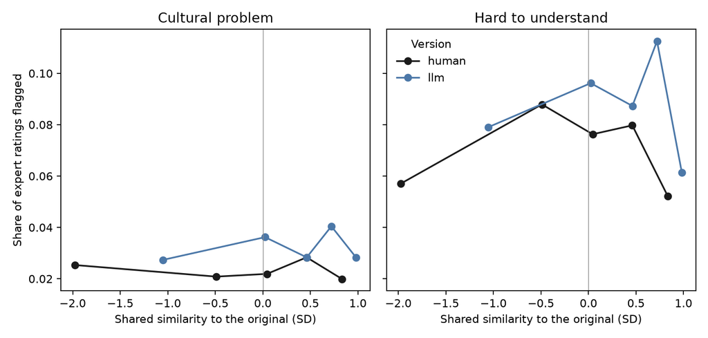

共有類似度の五分位

五分位の集計は、専門家問題チェックと類似度の関係を記述したものである。次に、同じ関係を回答者・尺度・項目の階層構造を考慮した二項ロジット混合モデルで検討する。各チェックは0/1の観測値をそのまま残す。式には、効果符号化した版、その版自身の項目類似度、回答者別・尺度別の版効果、項目切片、回答者×項目のペア切片を入れる。

| 専門家チェック | 人手版の傾き | LLM版の傾き | 人手 − LLMの傾き |
| --- | --- | --- | --- |
| 意味 | −0.298 [−0.415, −0.181] | −0.196 [−0.369, −0.023] | −0.102 [−0.294, 0.090] |
| 理解しにくさ | +0.164 [0.039, 0.290] | +0.219 [0.059, 0.379] | −0.055 [−0.229, 0.119] |
| 文化 | +0.076 [−0.101, 0.252] | +0.318 [0.067, 0.569] | −0.243 [−0.515, 0.030] |

各版自身の類似度が高いほど、意味チェックは両版で少なく、理解しにくさチェックは両版で多い。文化チェックはLLM版の類似度とともに増えるが、版間の傾き差は0を含む。

```r
raw_flags[
  raw_flags$term %in% c("sim_human", "sim_llm", "x:sim"),
  c("outcome", "term", "estimate", "ci_low", "ci_high")
]
```

```
# A tibble: 9 × 5
  outcome           term      estimate  ci_low ci_high
  <chr>             <chr>        <dbl>   <dbl>   <dbl>
1 semantic          x:sim      -0.102  -0.294   0.0897
2 semantic          sim_llm    -0.196  -0.369  -0.0229
3 semantic          sim_human  -0.298  -0.415  -0.181
4 understandability x:sim      -0.0550 -0.229   0.119
5 understandability sim_llm     0.219   0.0594  0.379
6 understandability sim_human   0.164   0.0388  0.290
7 cultural          x:sim      -0.243  -0.515   0.0297
8 cultural          sim_llm     0.318   0.0674  0.569
9 cultural          sim_human   0.0757 -0.101   0.252
```

### 6.8 探索的分析4：選好とLLM翻訳であるかどうか

選好とLLM翻訳であるかどうかは、もともと1つの二値判断である。したがって、差を作らず、人手版とLLM版の類似度を同時に入れた二項ロジット混合モデルを用いる。市民の選好では、人手版 −0.208 [−0.448, 0.031]、LLM版 +0.106 [−0.429, 0.642] である。LLM翻訳であるかどうかでは −0.182 [−0.385, 0.020] と +0.065 [−0.389, 0.518] である。いずれも0を含む。

選好とLLM翻訳であるかどうかについて、提示順効果も確認した。市民では、選好が +0.014 [−0.104, 0.132]、LLM版の指摘が −0.014 [−0.135, 0.107] で、いずれも0を含む。専門家では、LLM版の指摘は +0.047 [−0.512, 0.607] で0を含むが、選好は +0.717 [0.144, 1.290] で0を含まない。**すなわち、LLM版を先に見た専門家は人手版を選好するオッズが高かった（オッズ比 2.05 [1.15, 3.63]）**。この専門家選好の提示順効果だけが4モデル中で0を含まない。

```r
raw_choices[, c("outcome", "audience", "term", "estimate", "ci_low", "ci_high")]
```

```
# A tibble: 12 × 6
   outcome    audience term      estimate  ci_low ci_high
   <chr>      <chr>    <chr>        <dbl>   <dbl>   <dbl>
 1 preference citizen  sim_human  -0.208  -0.448   0.0312
 2 preference citizen  sim_llm     0.106  -0.429   0.642
 3 preference citizen  ai_first    0.0138 -0.104   0.132
 4 guess      citizen  sim_human  -0.182  -0.385   0.0205
 5 guess      citizen  sim_llm     0.0646 -0.389   0.518
 6 guess      citizen  ai_first   -0.0140 -0.135   0.107
 7 preference expert   sim_human  -0.263  -0.670   0.144
 8 preference expert   sim_llm     0.814  -0.0604  1.69
 9 preference expert   ai_first    0.717   0.144   1.29
10 guess      expert   sim_human  -0.153  -0.389   0.0829
11 guess      expert   sim_llm     0.373  -0.128   0.875
12 guess      expert   ai_first    0.0475 -0.512   0.607
```

## 7 参考情報

- 確認的な手順は `docs/PIPELINE.md`。
- Pythonの通し実行は `notebooks/h4_analysis.ipynb`。Rの通し実行は `notebooks/h4_replication.Rmd`。
- 回答者の個別データはこのHTMLに含まれない。公開されるのは係数と割合である。

解析の再現・除外とコーディングの規則